# Exercise week 6

Shawn Schneidereit

2021-05-30

### 7H3

#### part one

Notice that each row sums to 1, all the birds. This problem has two parts. It is not computationally complicated. But it is conceptually tricky. First, compute the entropy of each island’s bird distribution. Interpret these entropy values.

```r
# create df
islands <- tibble(island = paste("Island", 1:3),
       a = c(0.2, 0.8, 0.05),
       b = c(0.2, 0.1, 0.15),
       c = c(0.2, 0.05, 0.7),
       d = c(0.2, 0.025, 0.05),
       e = c(0.2, 0.025, 0.05)) %>%
  pivot_longer(-island, names_to = "species", values_to = "proportion")

(entropy <- islands %>%
  group_by(island) %>%
  summarize(entropy = -sum(proportion*log(proportion))))
```

```
## # A tibble: 3 x 2
##   island   entropy
##   <chr>      <dbl>
## 1 Island 1   1.61
## 2 Island 2   0.743
## 3 Island 3   0.984
```

Island 1 highest the highest level as entropy, as the probability of different bird species are the most equally distributed, meaning that the chance seeing any one species is not that surprising. on the flip side island has the lowest entropy, as the is a unbalanced distribution of probabilities, meaning that encountering any species that is not a would be far more surprising.

#### Part two

Second, use each island’s bird distribution to predict the other two. This means to compute the KL divergence of each island from the others, treating each island as if it were a statistical model of the other islands. You should end up with 6 different KL divergence values. Which island predicts the others best? Why?

```r
d_kl <- function(p, q) {
  sum(p * log(p/q))
}

KL_divergence <- c(1:6)
KL_divergence[1] <- d_kl(entropy$entropy[1], entropy$entropy[2])
KL_divergence[2] <-d_kl(entropy$entropy[1], entropy$entropy[3])
KL_divergence[3] <-d_kl(entropy$entropy[2], entropy$entropy[1])
KL_divergence[4] <-d_kl(entropy$entropy[2], entropy$entropy[3])
KL_divergence[5] <-d_kl(entropy$entropy[3], entropy$entropy[1])
KL_divergence[6] <-d_kl(entropy$entropy[3], entropy$entropy[2])
print(KL_divergence)
```

```
## [1]  1.2439972  0.7925205 -0.5742967 -0.2084262 -0.4843451  0.2759179
```

### Q2

Recall the divorce rate exercise from last week. Refit some of these models using brms, and compare them using the WAIC and PSIS-LOO estimates of ELPD. In particular, compare model m5.1 from the book with some of your models from last week including southernness as a predictor. Explain the model comparison results.

```r
data(WaffleDivorce, package = "rethinking")
d <- WaffleDivorce

d <-
  d %>%
  mutate(d = rethinking::standardize(Divorce),
         m = rethinking::standardize(Marriage),
         a = rethinking::standardize(MedianAgeMarriage))

b5.1 <-
  brm(data = d,
      family = gaussian,
      d ~ 1 + a,
      prior = c(prior(normal(0, 0.2), class = Intercept),
                prior(normal(0, 0.5), class = b),
                prior(exponential(1), class = sigma)),
      iter = 2000, warmup = 1000, chains = 4, cores = 4,
      seed = 42,
      sample_prior = T)


b5.shs <- brm(data = d,
      family = gaussian,
      d ~ 1 + South + m + a,
      prior = c(prior(normal(0, 0.2), class = Intercept),
                prior(normal(0, 0.5), class = b),
                prior(exponential(1), class = sigma)),
      iter = 2000, warmup = 1000, chains = 4,
      seed = 42)
b5.t1 <-
  brm(data = d,
      family = gaussian(link = "identity"),
      d ~ 1 + a,
      prior = c(prior(normal(0, 2.5), class = Intercept),
                prior(normal(0, 2.5), class = b),
                prior(exponential(1), class = sigma)),
      iter = 2000, warmup = 1000, chains = 4,
      seed = 42)
b5.t2 <-
  brm(data = d,
      family = gaussian(link = "identity"),
      d ~ 0 + South,
      prior = c(prior(normal(0, 2.5), class = b),
                prior(exponential(1), class = sigma)),
      iter = 2000, warmup = 1000, chains = 4,
      seed = 42)
b5.t3 <-
  brm(data = d,
      family = gaussian(link = "identity"),
      d ~ 0 + South + a,
      prior = c(prior(normal(0, 2.5), class = b),
                prior(exponential(1), class = sigma)),
      iter = 2000, warmup = 1000, chains = 4,
      seed = 42)
b5.1 <- add_criterion(b5.1, criterion = "waic")
b5.shs <- add_criterion(b5.shs, criterion = "waic")
b5.t1 <- add_criterion(b5.t1, criterion = "waic")
b5.t2 <- add_criterion(b5.t2, criterion = "waic")
b5.t3 <- add_criterion(b5.t3, criterion = "waic")
b_waic <- loo_compare(b5.1, b5.shs, b5.t1, b5.t2, b5.t3, criterion = "waic")

print(b_waic, simplify = F)
```

```
##        elpd_diff se_diff elpd_waic se_elpd_waic p_waic se_p_waic waic  se_waic
## b5.t3    0.0       0.0   -61.9       6.5          3.7    1.7     123.7  12.9
## b5.1    -1.0       1.3   -62.9       6.4          3.7    1.7     125.8  12.8
## b5.shs  -1.1       1.3   -62.9       6.2          5.2    1.8     125.9  12.4
## b5.t1   -1.5       1.2   -63.3       6.6          4.1    1.9     126.7  13.3
## b5.t2   -8.2       6.1   -70.1       4.2          1.6    0.3     140.1   8.4
```

```r
b5.1 <- add_criterion(b5.1, criterion = "loo")
b5.shs <- add_criterion(b5.shs, criterion = "loo")
b5.t1 <- add_criterion(b5.t1, criterion = "loo")
b5.t2 <- add_criterion(b5.t2, criterion = "loo")
b5.t3 <- add_criterion(b5.t3, criterion = "loo")

b_loo <- loo_compare(b5.1, b5.shs, b5.t1, b5.t2, b5.t3, criterion = "loo")

print(b_waic, simplify = F)
```

```
##        elpd_diff se_diff elpd_waic se_elpd_waic p_waic se_p_waic waic  se_waic
## b5.t3    0.0       0.0   -61.9       6.5          3.7    1.7     123.7  12.9
## b5.1    -1.0       1.3   -62.9       6.4          3.7    1.7     125.8  12.8
## b5.shs  -1.1       1.3   -62.9       6.2          5.2    1.8     125.9  12.4
## b5.t1   -1.5       1.2   -63.3       6.6          4.1    1.9     126.7  13.3
## b5.t2   -8.2       6.1   -70.1       4.2          1.6    0.3     140.1   8.4
```

```r
print(b_loo, simplify = F)
```

```
##        elpd_diff se_diff elpd_loo se_elpd_loo p_loo se_p_loo looic se_looic
## b5.t3    0.0       0.0   -62.0      6.6         3.9   1.9    124.0  13.1
## b5.1    -1.0       1.3   -63.1      6.5         3.8   1.9    126.1  13.0
## b5.shs  -1.1       1.4   -63.1      6.3         5.4   1.9    126.2  12.5
## b5.t1   -1.3       1.2   -63.4      6.6         4.1   2.0    126.7  13.3
## b5.t2   -8.1       6.2   -70.1      4.2         1.6   0.3    140.2   8.4
```

```r
# plot waic
library(rcartocolor)
carto_pal(7, "BurgYl")
```

```
## [1] "#fbe6c5" "#f5ba98" "#ee8a82" "#dc7176" "#c8586c" "#9c3f5d" "#70284a"
```

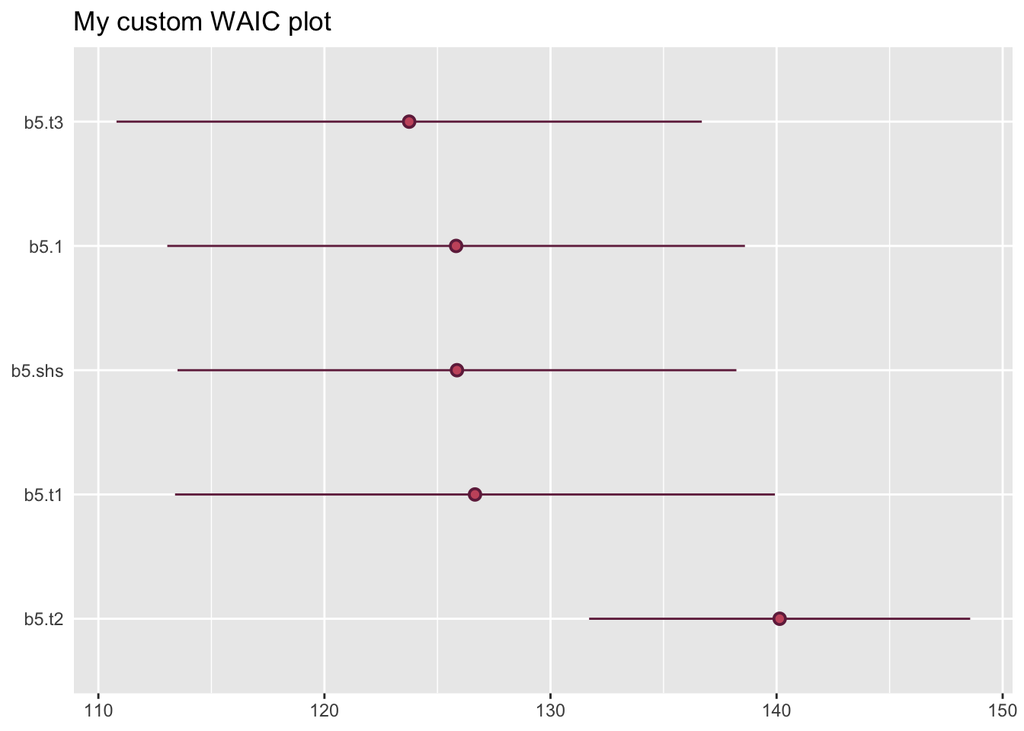

```r
b_waic[, 7:8] %>%
  data.frame() %>%
  rownames_to_column("model_name") %>%
  mutate(model_name = fct_reorder(model_name, waic, .desc = T)) %>%

  ggplot(aes(x = waic, y = model_name,
             xmin = waic - se_waic,
             xmax = waic + se_waic)) +
  geom_pointrange(color = carto_pal(7, "BurgYl")[7],
                  fill = carto_pal(7, "BurgYl")[5], shape = 21) +
  labs(title = "My custom WAIC plot",
       x = NULL, y = NULL) +
  theme(axis.ticks.y = element_blank())
```

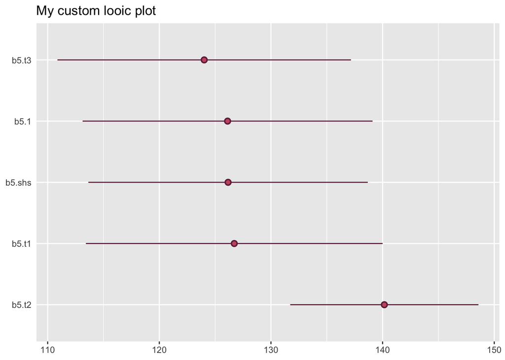

```r
# plot loo
b_loo[, 7:8] %>%
  data.frame() %>%
  rownames_to_column("model_name") %>%
  mutate(model_name = fct_reorder(model_name, looic, .desc = T)) %>%

  ggplot(aes(x = looic, y = model_name,
             xmin = looic - se_looic,
             xmax = looic + se_looic)) +
  geom_pointrange(color = carto_pal(7, "BurgYl")[7],
                  fill = carto_pal(7, "BurgYl")[5], shape = 21) +
  labs(title = "My custom looic plot",
       x = NULL, y = NULL) +
  theme(axis.ticks.y = element_blank())
```

In terms of general trends of model ranking, both WAIC and PSIS-LOO estimates of ELPD had complete correspondence with each other. According to McElreath this should not be a surprising result as WAIC and PSIS should perform very similarly in the context of ordinary linear models, and if there are large differences this would be an indication that one (or both) criteria are unreliable. Also estimates where very simular one thing to note is that for WAIC values a warning was given to use loo, as p_waic values where high. I assume that the tight correspondence between the two methods indicates that this message can be disregarded though?